# A Tutorial: Clustering Anonymized Mixed Data with MixClustVIjl

A worked example on the UCI Australian Credit Approval dataset — draft companion tutorial, to be published once the manuscript is posted to arXiv

> **Status note (remove before publishing).** This is a draft tutorial, written to accompany the paper *Local Feature Relevance and Cluster Order Selection in Model-Based Clustering for Mixed Data via Variational Inference*. It is not part of the manuscript itself and is held back from publication until the paper is posted to arXiv.

## 1 What This Tutorial Covers

The Iris tutorial showed the package on a small, well-understood continuous dataset. This one stress-tests a different axis: **how does `MixClustVIjl` perform when most features are categorical, some with many levels, and none carry any usable semantic meaning?** The UCI [Statlog Australian Credit Approval](https://archive.ics.uci.edu/dataset/143/statlog+australian+credit+approval) dataset is built for exactly this kind of test — and unlike Iris, it comes with a genuine binary outcome label (loan approved/rejected), so we can compute an Adjusted Rand Index (ARI) against external ground truth.

## 2 The Dataset

This dataset concerns credit card applications. Per the UCI documentation: *“All attribute names and values have been changed to meaningless symbols to protect confidentiality of the data.”* It has $n=690$ applications, 6 continuous and 8 categorical attributes (`A1`–`A14`), and a binary class label (1 = approved, 0 = rejected; 307 approved, 383 rejected). Missing values (5% of cases) were imputed in the standard release used here (mode for categorical, mean for continuous).

| Attribute | Type | Levels / notes |
| --- | --- | --- |
| `A1` | categorical | 2 levels |
| `A2` | continuous |  |
| `A3` | continuous |  |
| `A4` | categorical | 3 levels |
| `A5` | categorical | 14 levels |
| `A6` | categorical | 8 levels |
| `A7` | continuous |  |
| `A8` | categorical | 2 levels |
| `A9` | categorical | 2 levels |
| `A10` | continuous | integer-valued, zero-inflated (median 0, max 67) |
| `A11` | categorical | 2 levels |
| `A12` | categorical | 3 levels |
| `A13` | continuous |  |
| `A14` | continuous | extreme right skew — `log1p`-transformed before standardization |
| `class` | label (not a feature) | 1 = approved, 0 = rejected |

`A5` (14 levels) and `A6` (8 levels) make this a useful test of the Multinomial margin at higher cardinality than UCI Heart Disease or Iris.

## 3 Setup

```julia
using MixClustVIjl
using CSV, DataFrames, Statistics, Random, Printf
```

```
Precompiling packages...
   3920.1 ms  ✓ MixClustVIjl
  1 dependency successfully precompiled in 4 seconds. 192 already precompiled.
```

## 4 Loading and Preparing the Data

```julia
df = CSV.read(joinpath(@__DIR__, "../data/australian_credit.csv"), DataFrame)
println("n = $(nrow(df)),  columns = $(names(df))")
first(df, 3)
```

```
n = 690,  columns = ["A1", "A2", "A3", "A4", "A5", "A6", "A7", "A8", "A9", "A10", "A11", "A12", "A13", "A14", "class"]
```

3×15 DataFrame

| Row | A1 Int64 | A2 Float64 | A3 Float64 | A4 Int64 | A5 Int64 | A6 Int64 | A7 Float64 | A8 Int64 | A9 Int64 | A10 Int64 | A11 Int64 | A12 Int64 | A13 Int64 | A14 Int64 | class Int64 |
| --- | --- | --- | --- | --- | --- | --- | --- | --- | --- | --- | --- | --- | --- | --- | --- |
| 1 | 1 | 22.08 | 11.46 | 2 | 4 | 4 | 1.585 | 0 | 0 | 0 | 1 | 2 | 100 | 1213 | 0 |
| 2 | 0 | 22.67 | 7.0 | 2 | 8 | 4 | 0.165 | 0 | 0 | 0 | 0 | 2 | 160 | 1 | 0 |
| 3 | 0 | 29.58 | 1.75 | 1 | 4 | 4 | 1.25 | 0 | 0 | 0 | 1 | 2 | 280 | 1 | 0 |

```julia
feature_names = ["A2","A3","A7","A10","A13","A14","A1","A4","A5","A6","A8","A9","A11","A12"]

function onehot(val, levels)
    idx = findfirst(==(val), levels)
    isnothing(idx) && error("Value $val not in $levels")
    v = zeros(Int, length(levels)); v[idx] = 1; v
end

dataset = Vector{Any}(undef, 14)
dataset[1]  = Float64.(df.A2)
dataset[2]  = Float64.(df.A3)
dataset[3]  = Float64.(df.A7)
dataset[4]  = Float64.(df.A10)
dataset[5]  = Float64.(df.A13)
dataset[6]  = log1p.(Float64.(df.A14))   # log1p for extreme right skew
dataset[7]  = [onehot(x, [0, 1])              for x in df.A1]
dataset[8]  = [onehot(x, [1, 2, 3])           for x in df.A4]
dataset[9]  = [onehot(x, collect(1:14))       for x in df.A5]
dataset[10] = [onehot(x, [1,2,3,4,5,7,8,9])  for x in df.A6]
dataset[11] = [onehot(x, [0, 1])              for x in df.A8]
dataset[12] = [onehot(x, [0, 1])              for x in df.A9]
dataset[13] = [onehot(x, [0, 1])              for x in df.A11]
dataset[14] = [onehot(x, [1, 2, 3])           for x in df.A12]

# Standardize continuous features
for j in 1:6
    m = mean(dataset[j]); s = std(dataset[j])
    dataset[j] = (dataset[j] .- m) ./ s
end

labels_true = Vector{Int}(df.class)
println("Class distribution: $(count(==(1), labels_true)) approved, $(count(==(0), labels_true)) rejected")
```

```
Class distribution: 307 approved, 383 rejected
```

## 5 Fitting the Model

We fit both model settings with $K_{\text{fit}}=10$, $\alpha_0=0.01$.

### 5.1 SFRM — Shared Feature Relevance Model

```julia
Random.seed!(42)
res_sfrm = mixClust(dataset, 10;
                    model_setting = SFRM(),
                    alpha_0  = 0.01,
                    max_iter = 3000,
                    tol      = 1e-5,
                    prune    = true)

K_sfrm = size(res_sfrm.w, 2)
@printf("SFRM → K̂ = %d clusters (converged in %d / 3000 iterations)\n",
        K_sfrm, length(res_sfrm.elbo_history))
println("Cluster sizes: ", [count(==(k), res_sfrm.labels) for k in 1:K_sfrm])
```

```
SFRM → K̂ = 6 clusters (converged in 856 / 3000 iterations)
Cluster sizes: [21, 70, 71, 100, 374, 54]
```

### 5.2 LFRM — Local Feature Relevance Model

```julia
Random.seed!(42)
res_lfrm = mixClust(dataset, 10;
                    model_setting = LFRM(),
                    alpha_0  = 0.01,
                    max_iter = 3000,
                    tol      = 1e-5,
                    prune    = true)

K_lfrm = size(res_lfrm.w, 2)
@printf("LFRM → K̂ = %d clusters (converged in %d / 3000 iterations)\n",
        K_lfrm, length(res_lfrm.elbo_history))
println("Cluster sizes: ", [count(==(k), res_lfrm.labels) for k in 1:K_lfrm])
```

```
LFRM → K̂ = 5 clusters (converged in 2491 / 3000 iterations)
Cluster sizes: [71, 79, 102, 389, 49]
```

## 6 Diagnostics and Visualizations

### 6.1 Convergence

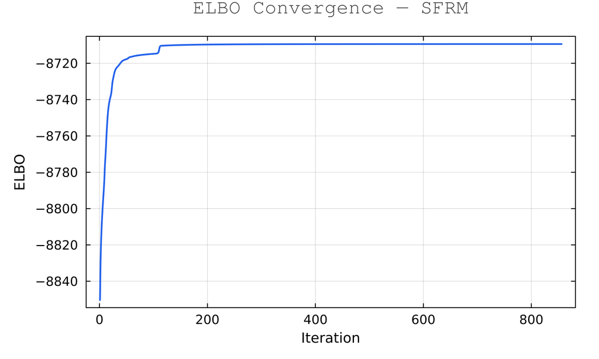

```julia
plot_elbo(res_sfrm; title = "ELBO Convergence — SFRM")
```

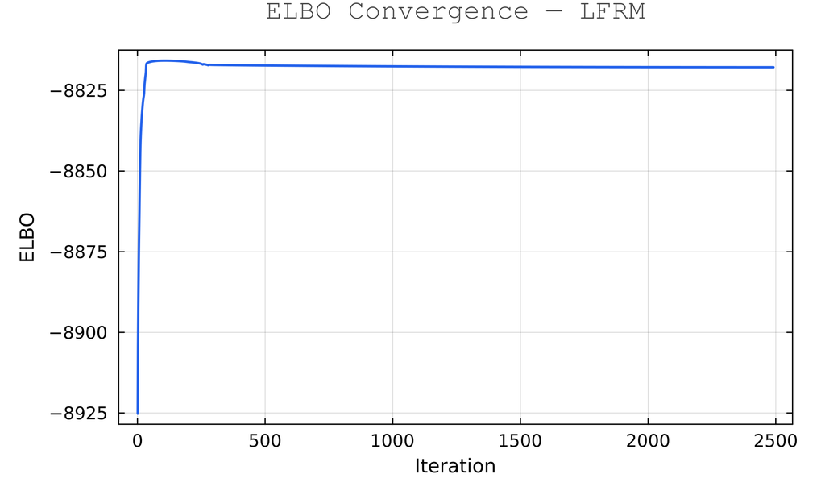

```julia
plot_elbo(res_lfrm; title = "ELBO Convergence — LFRM")
```

### 6.2 Cluster Sizes

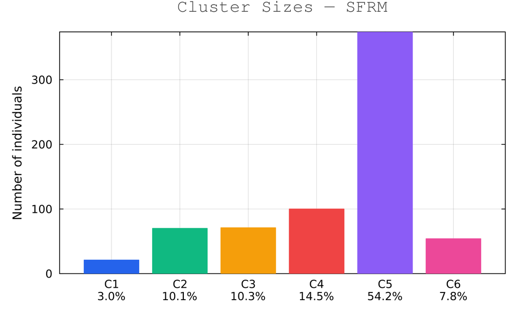

```julia
plot_cluster_sizes(res_sfrm; title = "Cluster Sizes — SFRM")
```

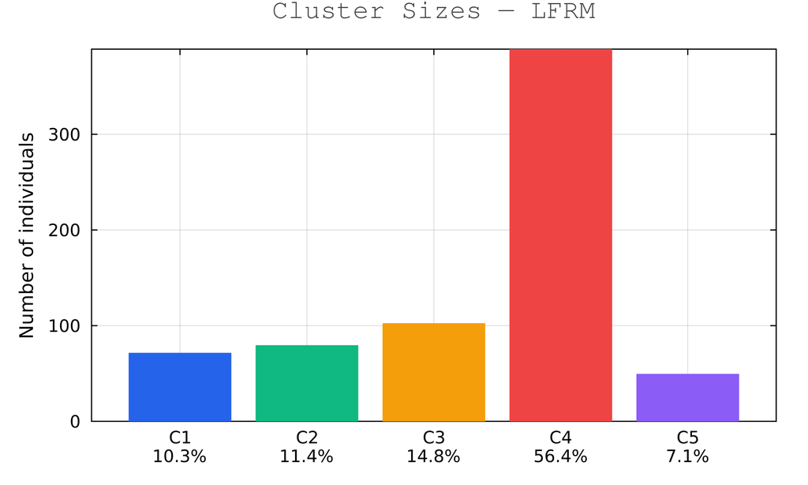

```julia
plot_cluster_sizes(res_lfrm; title = "Cluster Sizes — LFRM")
```

### 6.3 Assignment Confidence

With mostly categorical data and well-separated applicant profiles, we expect high confidence.

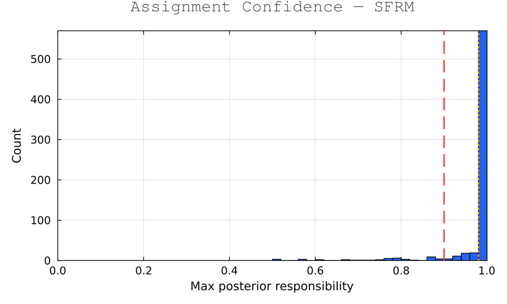

```julia
plot_assignment_confidence(res_sfrm; threshold = 0.9,
                           title = "Assignment Confidence — SFRM")
```

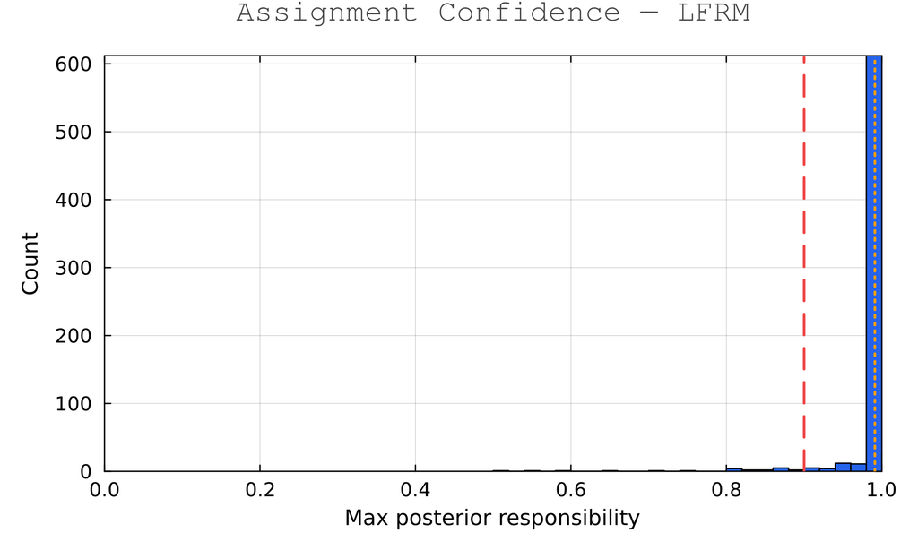

```julia
plot_assignment_confidence(res_lfrm; threshold = 0.9,
                           title = "Assignment Confidence — LFRM")
```

### 6.4 Feature Relevance — PIP

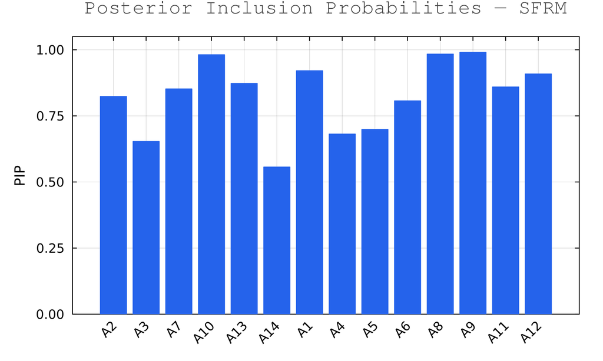

```julia
plot_pips(res_sfrm; feature_names = feature_names,
          title = "Posterior Inclusion Probabilities — SFRM")
```

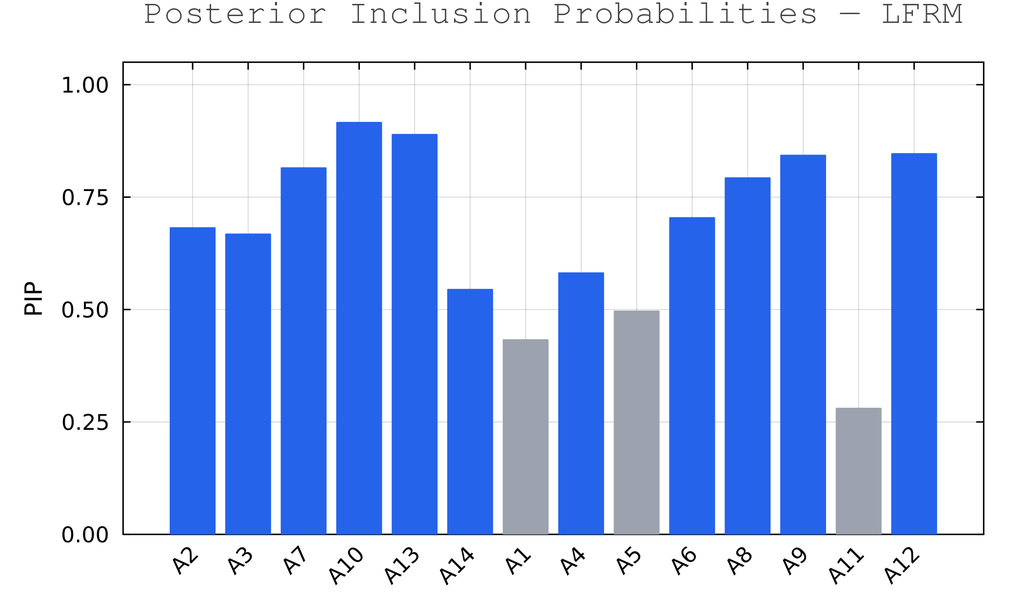

```julia
plot_pips(res_lfrm; feature_names = feature_names,
          title = "Posterior Inclusion Probabilities — LFRM")
```

### 6.5 Feature Relevance — EIG

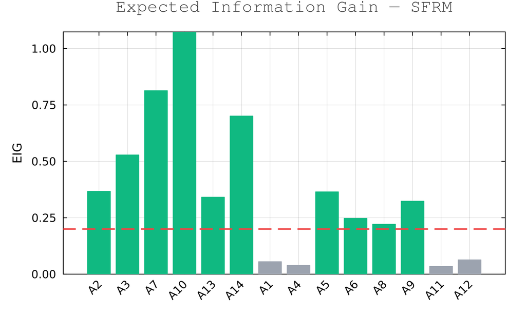

```julia
eig_sfrm = compute_eig(res_sfrm.margins, res_sfrm.w, res_sfrm.pip)
plot_eig(eig_sfrm, 0.20; feature_names = feature_names,
         title = "Expected Information Gain — SFRM")
```

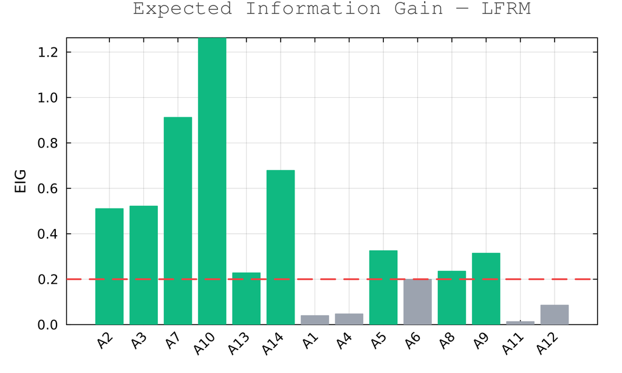

```julia
eig_lfrm = compute_eig(res_lfrm.margins, res_lfrm.w, res_lfrm.pip)
plot_eig(eig_lfrm, 0.20; feature_names = feature_names,
         title = "Expected Information Gain — LFRM")
```

```julia
active_sfrm = filter_features(eig_sfrm, 0.20)
active_lfrm = filter_features(eig_lfrm, 0.20)
println("SFRM active features (EIG ≥ 0.20): ", feature_names[active_sfrm])
println("LFRM active features (EIG ≥ 0.20): ", feature_names[active_lfrm])
```

```
SFRM active features (EIG ≥ 0.20): ["A2", "A3", "A7", "A10", "A13", "A14", "A5", "A6", "A8", "A9"]
LFRM active features (EIG ≥ 0.20): ["A2", "A3", "A7", "A10", "A13", "A14", "A5", "A8", "A9"]
```

### 6.6 Local PIPs (LFRM)

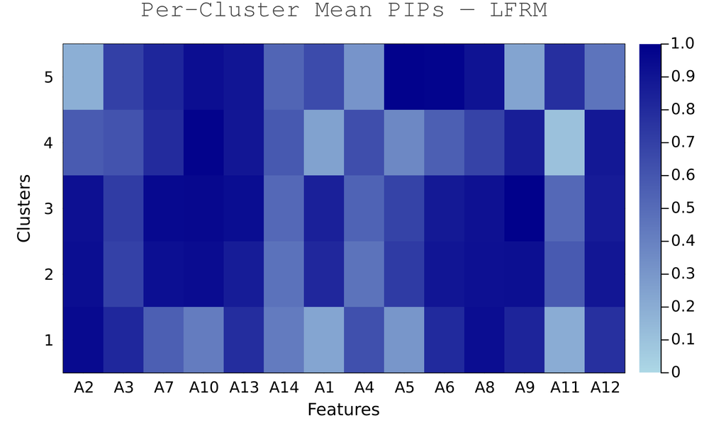

```julia
plot_local_pips(res_lfrm; feature_names = feature_names,
                title = "Per-Cluster Mean PIPs — LFRM")
```

### 6.7 Subtype Profiles

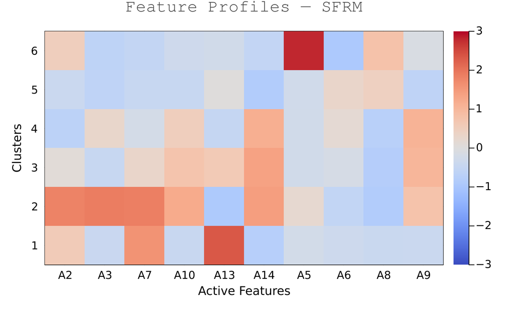

```julia
plot_profiles(res_sfrm, dataset; feature_names = feature_names,
              title = "Feature Profiles — SFRM")
```

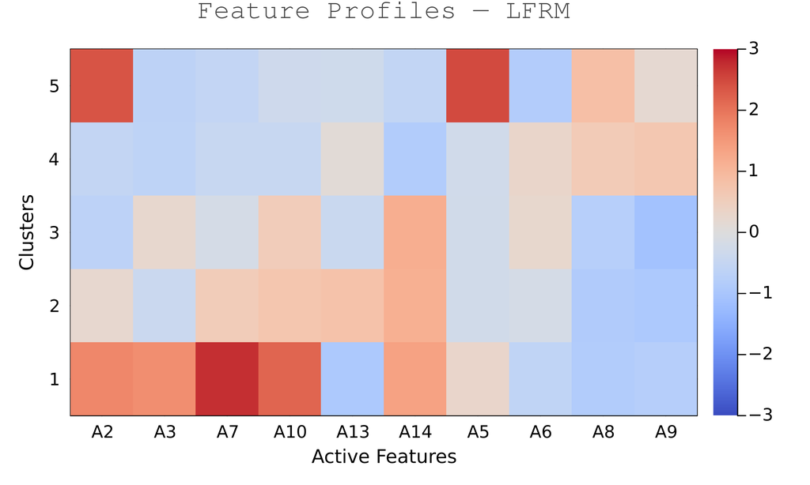

```julia
plot_profiles(res_lfrm, dataset; feature_names = feature_names,
              title = "Feature Profiles — LFRM")
```

### 6.8 Cluster Assignments in Feature Space

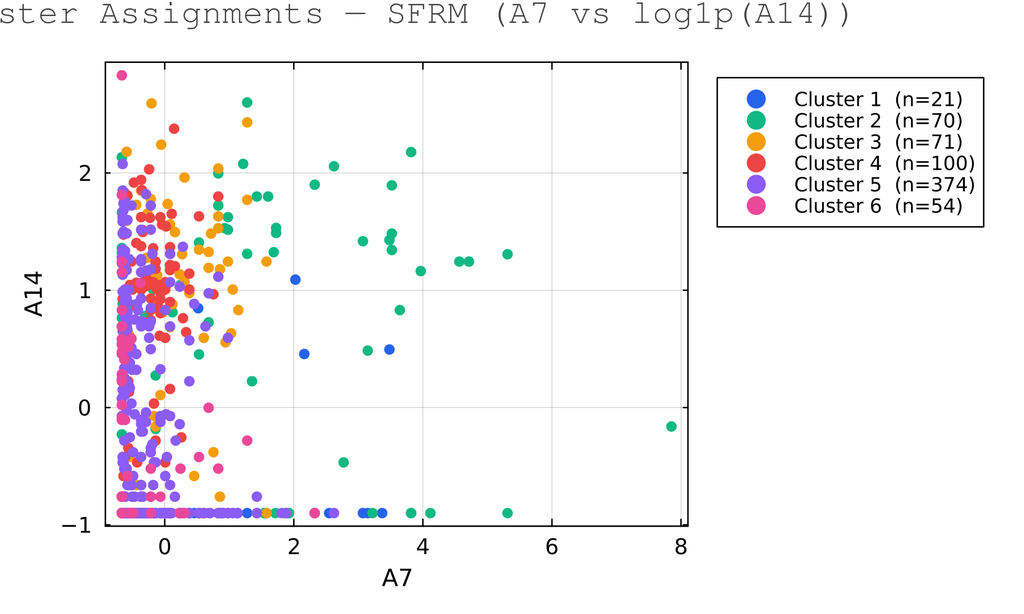

```julia
plot_assignments(res_sfrm, dataset;
                 x_feature = 3, y_feature = 6,
                 feature_names = feature_names,
                 title = "Cluster Assignments — SFRM (A7 vs log1p(A14))")
```

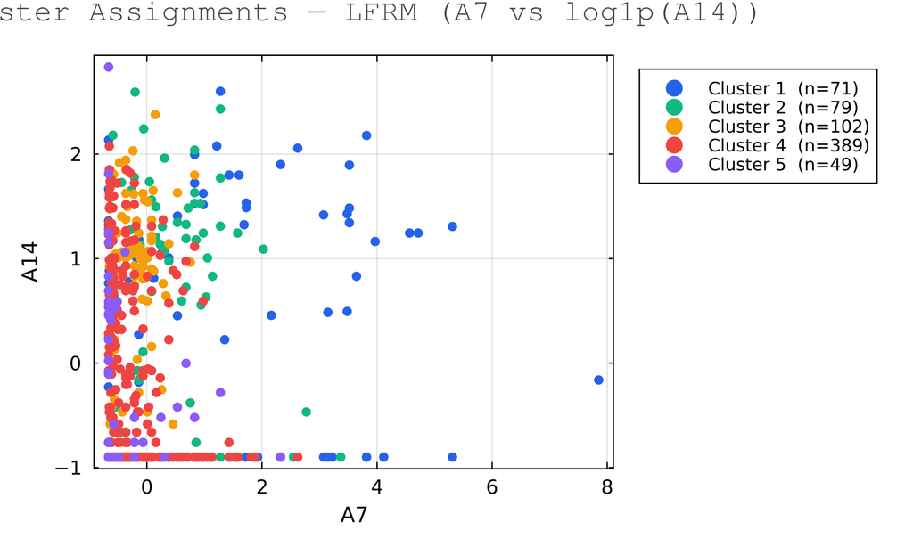

```julia
plot_assignments(res_lfrm, dataset;
                 x_feature = 3, y_feature = 6,
                 feature_names = feature_names,
                 title = "Cluster Assignments — LFRM (A7 vs log1p(A14))")
```

## 7 External Validation: A Cautionary Result

Unlike Iris, this dataset has a real binary outcome — the credit approval decision — so we can compute ARI against it. The result is worth reporting honestly.

```julia
function compute_ari(labels_true, labels_pred)
    n = length(labels_true)
    classes  = unique(labels_true)
    clusters = unique(labels_pred)
    C, K = length(classes), length(clusters)
    cont = zeros(Int, C, K)
    for i in 1:n
        ci = findfirst(==(labels_true[i]),  classes)
        ki = findfirst(==(labels_pred[i]), clusters)
        cont[ci, ki] += 1
    end
    s_ij = sum(x -> x*(x-1)/2, cont)
    s_i  = sum(x -> x*(x-1)/2, sum(cont, dims=2))
    s_j  = sum(x -> x*(x-1)/2, sum(cont, dims=1))
    exp  = (s_i * s_j) / (n*(n-1)/2)
    mx   = 0.5*(s_i + s_j)
    mx == exp && return 1.0
    return (s_ij - exp) / (mx - exp)
end

ari_sfrm = compute_ari(labels_true, res_sfrm.labels)
ari_lfrm = compute_ari(labels_true, res_lfrm.labels)

conf_sfrm = mean(maximum(res_sfrm.w[i, :]) for i in 1:nrow(df))
conf_lfrm = mean(maximum(res_lfrm.w[i, :]) for i in 1:nrow(df))

println("Summary")
println("─────────────────────────────────────────────")
@printf("  %-6s  K̂ = %d   ARI = %.3f   confidence = %.3f\n",
        "SFRM", K_sfrm, ari_sfrm, conf_sfrm)
@printf("  %-6s  K̂ = %d   ARI = %.3f   confidence = %.3f\n",
        "LFRM", K_lfrm, ari_lfrm, conf_lfrm)
```

```
Summary
─────────────────────────────────────────────
  SFRM    K̂ = 6   ARI = 0.217   confidence = 0.980
  LFRM    K̂ = 5   ARI = 0.222   confidence = 0.991
```

Both SFRM and LFRM score *below* plain K-means (K=2 fixed, ARI ≈ 0.314) — the opposite of the UCI Heart Disease result. The reason: K-means forced to $K=2$ is by construction aligned with a binary label. Our model finds finer subpopulation structure ($\widehat{K}=5$–$6$) than the approve/reject boundary distinguishes, which mechanically incurs ARI penalties even when the finer clusters are internally coherent — as the assignment-confidence numbers above confirm.

**Note**

**ARI against a binary label is not a fair test of automatic order selection.** A finer, more confident partition that subdivides each side of the true binary decision will always be penalized by ARI against that label, even if it is a better description of the actual feature-space structure. Whether to trust the automatically selected $\widehat{K}$ or to also check against a label-matched $K$ depends on whether the label itself reflects the population’s true subgroup structure.

## 8 Does the Cluster Structure Help Downstream Prediction?

We tested two ways to exploit the discovered cluster structure for predicting loan approval, using 10-fold stratified cross-validation (Python scripts `experiments/scripts/australian_predictive_cv.py` and `australian_moe_cv.py`):

1. **Feature augmentation** — soft cluster-membership weights added as extra predictors.
2. **Mixture of experts** — a separate classifier per cluster, weighted by membership.

| Feature set | Classifier | Accuracy | AUC |
| --- | --- | --- | --- |
| Baseline (raw features) | LogisticRegression | 0.859 ± 0.049 | 0.928 ± 0.040 |
| Baseline (raw features) | RandomForest | 0.870 ± 0.040 | 0.934 ± 0.040 |
| + SFRM cluster membership | LogisticRegression | 0.861 ± 0.045 | 0.930 ± 0.037 |
| + SFRM cluster membership | RandomForest | 0.870 ± 0.055 | 0.930 ± 0.042 |
| + LFRM cluster membership | LogisticRegression | 0.858 ± 0.046 | 0.928 ± 0.039 |
| + LFRM cluster membership | RandomForest | 0.862 ± 0.048 | 0.931 ± 0.042 |
| Mixture of experts, SFRM | per-cluster LogisticRegression | 0.852 ± 0.053 | 0.910 ± 0.041 |
| Mixture of experts, LFRM | per-cluster LogisticRegression | 0.852 ± 0.061 | 0.907 ± 0.047 |

Neither approach helps. Feature augmentation is a wash; the mixture of experts is slightly *worse* (splitting $n=690$ into 5–6 per-cluster regressions leaves too few observations per expert). This is a useful negative result: discovering finer cluster structure does not automatically translate into better downstream prediction at this sample size.

## 9 Takeaways

- `MixClustVIjl` handles high-cardinality categorical features (up to 14 levels) and a fully anonymized feature set without numerical difficulty.
- LFRM surfaces features whose relevance is locally concentrated rather than uniform — consistent with the pattern found on UCI Heart Disease in the main manuscript.
- **ARI against an external label is not always going to favor automatic order selection over a fixed-$K$ baseline** — and that is not necessarily a failure of the method.
- **Discovering finer cluster structure does not automatically translate into better downstream prediction** — a useful negative result for anyone tempted to assume “more structure found” implies “more useful for prediction.”